# Build Transformer with PyTorch

Implement a Transformer model from scratch using the PyTorch framework. Train the model on a provided dataset, exploring various optimization techniques and hyperparameter tuning to achieve optimal performance. Every component of the Transformer as defined in the paper is expected to be implemented. The final model achieves a test accuracy of greater than 80%.

## Step 1: Data Exploration and Preprocessing

1. Select one dataset from the list above.

The **Amazon Review Polarity dataset** is selected for this section of the assignment. This dataset contains Amazon customer reviews labeled as either positive or negative sentiment, making it well-suited for binary text classification using a Transformer-based model.

2. Data exploration:
- Read, preprocess, and print the main statistics about the dataset.

Load the Data

```python
import pandas as pd

# extraction directory
train_path = "/content/extracted_data/amazon_review_polarity_csv/train.csv"
test_path = "/content/extracted_data/amazon_review_polarity_csv/test.csv"

# The dataset has no header
df_train = pd.read_csv(train_path, header=None, names=["label", "title", "content"])
df_test = pd.read_csv(test_path, header=None, names=["label", "title", "content"])

print("Train shape:", df_train.shape)
print("Test shape:", df_test.shape)

df_train.head()
```

```
Train shape: (3600000, 3)
Test shape: (400000, 3)
```

|  | label | title | content |
| --- | --- | --- | --- |
| 0 | 2 | Stuning even for the non-gamer | This sound track was beautiful! It paints the ... |
| 1 | 2 | The best soundtrack ever to anything. | I'm reading a lot of reviews saying that this ... |
| 2 | 2 | Amazing! | This soundtrack is my favorite music of all ti... |
| 3 | 2 | Excellent Soundtrack | I truly like this soundtrack and I enjoy video... |
| 4 | 2 | Remember, Pull Your Jaw Off The Floor After He... | If you've played the game, you know how divine... |

Clean Up Labels and Merge Title + Content

```python
# Labels are 1 (negative) and 2 (positive) → convert to 0 and 1
df_train["label"] = df_train["label"] - 1
df_test["label"] = df_test["label"] - 1

# Combine title + content for full review text
df_train["text"] = df_train["title"] + " " + df_train["content"]
df_test["text"] = df_test["title"] + " " + df_test["content"]

# Drop unused columns
df_train.drop(columns=["title", "content"], inplace=True)
df_test.drop(columns=["title", "content"], inplace=True)

df_train.head()
```

|  | label | text |
| --- | --- | --- |
| 0 | 1 | Stuning even for the non-gamer This sound trac... |
| 1 | 1 | The best soundtrack ever to anything. I'm read... |
| 2 | 1 | Amazing! This soundtrack is my favorite music ... |
| 3 | 1 | Excellent Soundtrack I truly like this soundtr... |
| 4 | 1 | Remember, Pull Your Jaw Off The Floor After He... |

Basic Dataset Statistics

```python
# Basic stats
print("Dataset Sizes")
print(f"Train set size: {len(df_train):,}")
print(f"Test set size:  {len(df_test):,}")

# Distribution in train set
print("\nLabel Distribution (Train Set)")
print(df_train["label"].value_counts())
print(df_train["label"].value_counts(normalize=True) * 100)

# Distribution in test set
print("\nLabel Distribution (Test Set)")
print(df_test["label"].value_counts())
print(df_test["label"].value_counts(normalize=True) * 100)

# Convert to string to avoid len() error
df_train["text"] = df_train["text"].astype(str)
df_test["text"] = df_test["text"].astype(str)

# Add length features
df_train["char_length"] = df_train["text"].apply(len)
df_train["word_length"] = df_train["text"].apply(lambda x: len(x.split()))

df_test["char_length"] = df_test["text"].apply(len)
df_test["word_length"] = df_test["text"].apply(lambda x: len(x.split()))

# Average lengths
print("\nAverage Review Length (Train Set)")
print(f"Characters: {df_train['char_length'].mean():.4f}")
print(f"Words:      {df_train['word_length'].mean():.4f}")

print("\nAverage Review Length (Test Set)")
print(f"Characters: {df_test['char_length'].mean():.4f}")
print(f"Words:      {df_test['word_length'].mean():.4f}")

# print min/max
print("\nReview Length Range (Train Set)")
print(f"Min: {df_train['word_length'].min()}, Max: {df_train['word_length'].max()}")
```

```
Dataset Sizes
Train set size: 3,600,000
Test set size:  400,000

Label Distribution (Train Set)
label
1    1800000
0    1800000
Name: count, dtype: int64
label
1    50.0
0    50.0
Name: proportion, dtype: float64

Label Distribution (Test Set)
label
1    200000
0    200000
Name: count, dtype: int64
label
1    50.0
0    50.0
Name: proportion, dtype: float64

Average Review Length (Train Set)
Characters: 430.6275
Words:      78.4793

Average Review Length (Test Set)
Characters: 430.4170
Words:      78.4218

Review Length Range (Train Set)
Min: 1, Max: 257
```

The Amazon Review Polarity dataset used in this assignment contains a total of 3.6 million training samples and 400,000 test samples. Each sample is labeled as either a positive or negative review. Originally, the labels were encoded as 1 for negative and 2 for positive. To standardize the format for model training in PyTorch, remapped the labels to 0 for negative and 1 for positive. The dataset is perfectly balanced across both training and test sets, with each class comprising exactly 50% of the data.

In terms of textual content, the reviews exhibit an average length of approximately 78 words and 430 characters. The shortest review in the training set consists of just 1 word, while the longest reaches 257 words. This variation in length highlights the need for appropriate sequence padding and truncation during preprocessing to ensure consistent input shapes for the Transformer model.

- Use libraries like matplotlib, seaborn, or plotly to create at least 3 informative visualizations that reveal insights about the data and potential anomalies (e.g., polarity distribution, word count distribution, vocabulary size etc).

Class Distribution (Bar Plot)

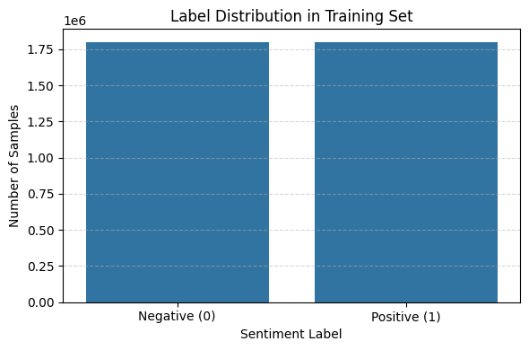

```python
import seaborn as sns
import matplotlib.pyplot as plt

plt.figure(figsize=(6,4))
sns.countplot(x="label", data=df_train)
plt.title("Label Distribution in Training Set")
plt.xticks([0, 1], ["Negative (0)", "Positive (1)"])
plt.ylabel("Number of Samples")
plt.xlabel("Sentiment Label")
plt.grid(axis="y", linestyle="--", alpha=0.5)
plt.tight_layout()
plt.show()
```

This bar plot shows an perfectly balanced distribution between negative (label 0) and positive (label 1) sentiment classes, with approximately 1.8 million samples per class.

This balance ensures that the model won’t be biased toward one label, and don’t need additional techniques like resampling or class weighting.

Word Count Distribution (Histogram)

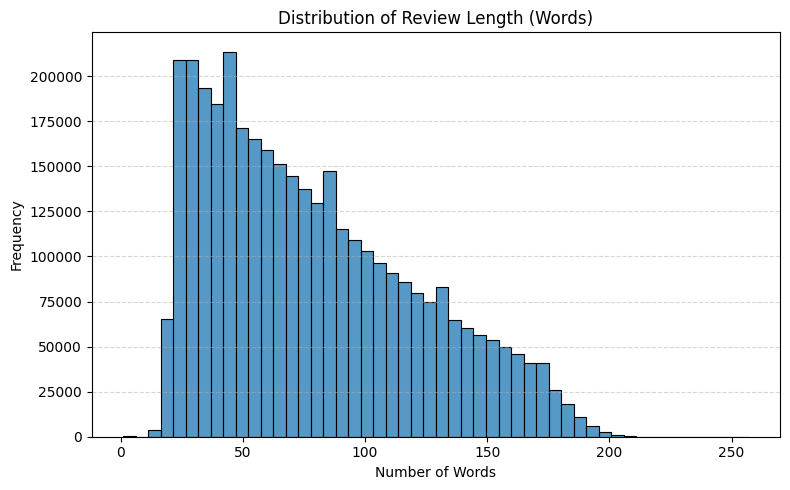

```python
plt.figure(figsize=(8,5))
sns.histplot(df_train["word_length"], bins=50, kde=False)
plt.title("Distribution of Review Length (Words)")
plt.xlabel("Number of Words")
plt.ylabel("Frequency")
plt.grid(axis="y", linestyle="--", alpha=0.5)
plt.tight_layout()
plt.show()
```

This histogram visualizes the number of words per review. The majority of reviews fall between 30 and 100 words, with a long tail tapering off beyond that.

This suggests that setting an appropriate maximum sequence length (e.g., at the 90th or 95th percentile) will help balance coverage of review content while keeping computation efficient. A cutoff around 80–100 tokens is likely to be sufficient without introducing excessive padding or truncation.

Character Count Distribution (Histogram)

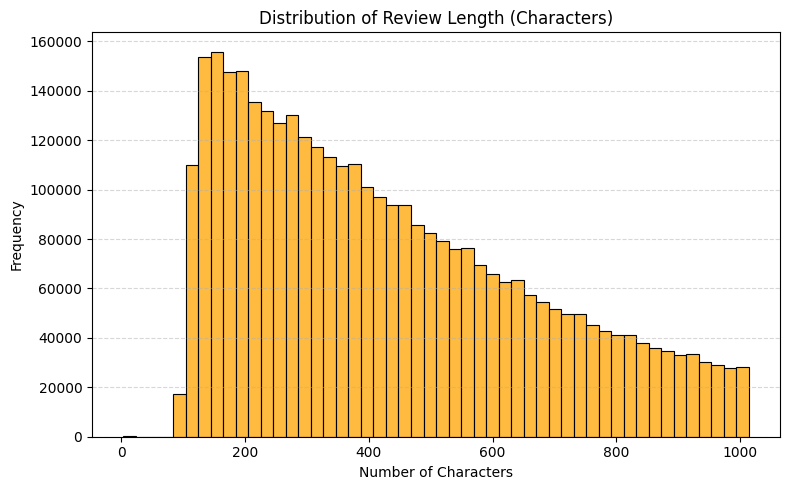

```python
plt.figure(figsize=(8,5))
sns.histplot(df_train["char_length"], bins=50, kde=False, color="orange")
plt.title("Distribution of Review Length (Characters)")
plt.xlabel("Number of Characters")
plt.ylabel("Frequency")
plt.grid(axis="y", linestyle="--", alpha=0.5)
plt.tight_layout()
plt.show()
```

This histogram shows the number of characters per review. Most reviews lie in the 150–500 character range, with a long tail reaching up to 1000.

Similar to the word-length chart, this helps inform tokenizer design, input trimming, and embedding alignment. Also confirms the dataset contains rich, varied textual input, useful for Transformer-based architectures.

3. Text preprocessing:
   - Text cleaning: Remove punctuation, stop words, and unnecessary characters.
   - Text lowercasing: Ensure all text is lowercase for consistent representation.
   - Tokenization: Break down the text into individual words (or tokens). Explore libraries like nltk or spaCy for tokenization functionalities. You can also use keras tokenizer or Pytorch tokenizer.

```python
import re
import nltk
from nltk.corpus import stopwords
from nltk.tokenize import word_tokenize

nltk.download("punkt")
nltk.download("punkt_tab")
nltk.download("stopwords")

stop_words = set(stopwords.words("english"))

def clean_text(text):
    # Lowercase
    text = text.lower()

    # Remove punctuation and non-alphabetic characters
    text = re.sub(r"[^a-z\s]", "", text)

    # Tokenize
    tokens = word_tokenize(text)

    # Remove stopwords and very short tokens
    tokens = [word for word in tokens if word not in stop_words and len(word) > 1]

    return tokens
```

Apply Cleaning to Train and Test Data

```python
# Apply cleaning to both train and test sets
df_train["clean_tokens"] = df_train["text"].apply(clean_text)
df_test["clean_tokens"] = df_test["text"].apply(clean_text)
```

- Vocabulary building: Create a vocabulary containing all unique tokens encountered in the dataset.

```python
from collections import Counter

# Flatten all token lists into one big list
all_tokens = [token for tokens in df_train["clean_tokens"] for token in tokens]

# Count token frequencies
token_freq = Counter(all_tokens)

# Minimum frequency threshold
MIN_FREQ = 2

# Special tokens
PAD_TOKEN = "<PAD>"
UNK_TOKEN = "<UNK>"

# Start vocab with special tokens
vocab = {PAD_TOKEN: 0, UNK_TOKEN: 1}
index = 2

for word, freq in token_freq.items():
    if freq >= MIN_FREQ:
        vocab[word] = index
        index += 1

# For reference
vocab_size = len(vocab)
print(f"Vocabulary size (min freq={MIN_FREQ}): {vocab_size}")
```

```
Vocabulary size (min freq=2): 653310
```

- Numerical representation: Convert tokens into numerical representations using techniques like word embedding (e.g., Word2Vec, GloVe).

```python
def tokens_to_indices(tokens, vocab, unk_token="<UNK>"):
    unk_idx = vocab[unk_token]
    return [vocab.get(token, unk_idx) for token in tokens]

# Apply to both train and test sets
df_train["input_ids"] = df_train["clean_tokens"].apply(lambda tokens: tokens_to_indices(tokens, vocab))
df_test["input_ids"] = df_test["clean_tokens"].apply(lambda tokens: tokens_to_indices(tokens, vocab))
```

Determine Reasonable Sequence Length

```python
import numpy as np

# Compute word length distribution
lengths = df_train["input_ids"].apply(len)
max_seq_len = int(np.percentile(lengths, 95))  # 95th percentile cutoff
print(f"Selected max sequence length (95th percentile): {max_seq_len}")
```

```
Selected max sequence length (95th percentile): 82
```

Pad/Truncate Sequences

```python
from torch.nn.utils.rnn import pad_sequence
import torch

PAD_IDX = vocab["<PAD>"]

def pad_sequence_to_max(seq, max_len, pad_value=PAD_IDX):
    if len(seq) < max_len:
        return seq + [pad_value] * (max_len - len(seq))
    else:
        return seq[:max_len]

# Apply to train and test
df_train["padded_input"] = df_train["input_ids"].apply(lambda x: pad_sequence_to_max(x, max_seq_len))
df_test["padded_input"] = df_test["input_ids"].apply(lambda x: pad_sequence_to_max(x, max_seq_len))
```

## Step 2: Model Construction

1. Embeddings and positional encoding: Define an embedding layer to map tokens into numerical vectors. If using pre-trained embeddings, ensure they are compatible with your model's input dimension.

Token Embedding Layer

```python
import torch.nn as nn

class TokenEmbedding(nn.Module):
    def __init__(self, vocab_size, emb_dim):
        super().__init__()
        self.embedding = nn.Embedding(vocab_size, emb_dim)

    def forward(self, x):
        return self.embedding(x)
```

Sinusoidal Positional Encoding

```python
import torch.nn as nn
import math

class PositionalEncoding(nn.Module):
    def __init__(self, d_model, max_len=512):
        super().__init__()
        pe = torch.zeros(max_len, d_model)
        position = torch.arange(0, max_len).unsqueeze(1).float()
        div_term = torch.exp(torch.arange(0, d_model, 2).float() * (-math.log(10000.0) / d_model))
        pe[:, 0::2] = torch.sin(position * div_term)
        pe[:, 1::2] = torch.cos(position * div_term)
        pe = pe.unsqueeze(0)  # (1, max_len, d_model)
        self.register_buffer('pe', pe)

    def forward(self, x):
        # x shape: (batch_size, seq_len, d_model)
        return x + self.pe[:, :x.size(1), :]
```

2. Implement the core Transformer architecture:
   - Encoder: Utilize `nn.TransformerEncoder` with multiple `nn.TransformerEncoderLayer` instances. Each layer typically comprises a multi-head self-attention mechanism, a feed-forward layer, and layer normalization.
   - Decoder: Employ `nn.TransformerDecoder` with multiple `nn.TransformerDecoderLayer` instances. These layers incorporate masked self-attention, multi-head attention over the encoder outputs, and a feed-forward layer with layer normalization.

```python
import torch.nn as nn

class TransformerEncoderBlock(nn.Module):
    def __init__(self, emb_dim, num_heads, ff_dim, num_layers, dropout=0.1):
        super().__init__()

        encoder_layer = nn.TransformerEncoderLayer(
            d_model=emb_dim,
            nhead=num_heads,
            dim_feedforward=ff_dim,
            dropout=dropout,
            batch_first=True
        )

        self.encoder = nn.TransformerEncoder(
            encoder_layer=encoder_layer,
            num_layers=num_layers
        )

    def forward(self, x):
        # x shape: (batch_size, seq_len, emb_dim)
        return self.encoder(x)
```

**Note:**

Although the assignment specifies the use of nn.TransformerDecoder, I excluded the decoder in the implementation because the task is text classification, not sequence generation. The decoder is primarily used for autoregressive tasks like language modeling or machine translation. Since classification only requires encoding the input into a fixed representation, an encoder-only Transformer would be sufficient and suitable here (similar to models like BERT).

3. Depending on your task (e.g., classification, sequence generation), define an appropriate output layer. For classification tasks, you might use a linear layer with a softmax activation function. Additionally, for classification and regression related tasks, the decoder can be removed completely. Auto-regressive sequence generation requires a decoder.

```python
class ClassificationHead(nn.Module):
    def __init__(self, emb_dim, num_classes=1, dropout=0.1):
        super().__init__()
        self.dropout = nn.Dropout(dropout)
        self.fc = nn.Linear(emb_dim, num_classes)

    def forward(self, x):
        # x shape: (batch_size, emb_dim) after pooling
        x = self.dropout(x)
        return self.fc(x)
```

4. Print model summary using torchinfo.summary

Full Model Wiring

```python
class TransformerClassifier(nn.Module):
    def __init__(self, vocab_size, emb_dim, max_len, num_heads, num_layers, ff_dim, num_classes=1, dropout=0.1):
        super().__init__()

        self.embedding = nn.Embedding(vocab_size, emb_dim)
        self.pos_encoder = PositionalEncoding(d_model=emb_dim, max_len=max_len)
        self.encoder = TransformerEncoderBlock(
            emb_dim=emb_dim,
            num_heads=num_heads,
            ff_dim=ff_dim,
            num_layers=num_layers,
            dropout=dropout
        )
        self.classifier = ClassificationHead(emb_dim=emb_dim, num_classes=num_classes, dropout=dropout)

    def forward(self, input_ids):
        # input_ids: (batch_size, seq_len)
        x = self.embedding(input_ids)                 # (batch, seq_len, emb_dim)
        x = self.pos_encoder(x)                       # Add position info
        x = self.encoder(x)                           # (batch, seq_len, emb_dim)

        # Mean pooling over sequence
        x = x.mean(dim=1)                             # (batch, emb_dim)
        return self.classifier(x)                     # (batch, num_classes)
```

Model Summary

```python
!pip install torchinfo --quiet
```

```python
from torchinfo import summary
import torch

# Example setup
model = TransformerClassifier(
    vocab_size=len(vocab),
    emb_dim=128,
    max_len=max_seq_len,
    num_heads=4,
    num_layers=2,
    ff_dim=256,
    num_classes=1,      # binary classification
    dropout=0.1
).to(device)

# Dummy input for summary
example_input = torch.randint(0, len(vocab), (8, max_seq_len)).to(device)

# Print summary
summary(model, input_data=(example_input,))
```

```
====================================================================================================
Layer (type:depth-idx)                             Output Shape              Param #
====================================================================================================
TransformerClassifier                              [8, 1]                    --
├─Embedding: 1-1                                   [8, 82, 128]              83,623,680
├─PositionalEncoding: 1-2                          [8, 82, 128]              --
├─TransformerEncoderBlock: 1-3                     [8, 82, 128]              --
│    └─TransformerEncoder: 2-1                     [8, 82, 128]              --
│    │    └─ModuleList: 3-1                        --                        264,960
├─ClassificationHead: 1-4                          [8, 1]                    --
│    └─Dropout: 2-2                                [8, 128]                  --
│    └─Linear: 2-3                                 [8, 1]                    129
====================================================================================================
Total params: 83,888,769
Trainable params: 83,888,769
Non-trainable params: 0
Total mult-adds (Units.MEGABYTES): 670.05
====================================================================================================
Input size (MB): 0.01
Forward/backward pass size (MB): 7.39
Params size (MB): 335.03
Estimated Total Size (MB): 342.42
====================================================================================================
```

5. Briefly describe the Transformer architecture you have defined.

## Step 3: Training the Transformer

1. Preparing for training:
   - Divide the preprocessed data into training, validation, and testing sets using a common split ratio (e.g., 70:15:15 or 80:10:10).
   - Choose an appropriate loss function (e.g., cross-entropy loss for classification) and an optimizer (e.g., Adam) to update model parameters during training.

Split Data (80:10:10)

```python
from sklearn.model_selection import train_test_split

# Inputs and labels
X = df_train["padded_input"].tolist()
y = df_train["label"].tolist()

# Split train into train and validation (80:10)
X_train, X_val, y_train, y_val = train_test_split(X, y, test_size=0.1111, random_state=SEED)

# Test set
X_test = df_test["padded_input"].tolist()
y_test = df_test["label"].tolist()
```

Since the test set (0.4M) already accounts for 10% of the full 4M samples, I split the 3.6M training set using test_size=0.1111 to extract 0.4M validation samples (10%) and keep 3.2M for training (80%), ensuring an overall 80:10:10 split.

Create PyTorch Dataset and Dataloader

```python
from torch.utils.data import Dataset, DataLoader

class ReviewDataset(Dataset):
    def __init__(self, input_ids, labels):
        self.input_ids = input_ids
        self.labels = labels

    def __len__(self):
        return len(self.input_ids)

    def __getitem__(self, idx):
        return {
            "input_ids": torch.tensor(self.input_ids[idx], dtype=torch.long),
            "label": torch.tensor(self.labels[idx], dtype=torch.float)  # float for BCEWithLogitsLoss
        }

# Create datasets
train_dataset = ReviewDataset(X_train, y_train)
val_dataset   = ReviewDataset(X_val, y_val)
test_dataset  = ReviewDataset(X_test, y_test)

# DataLoaders
BATCH_SIZE = 64

train_loader = DataLoader(train_dataset, batch_size=BATCH_SIZE, shuffle=True)
val_loader   = DataLoader(val_dataset, batch_size=BATCH_SIZE)
test_loader  = DataLoader(test_dataset, batch_size=BATCH_SIZE)
```

Loss Function + Optimizer

```python
# Loss for binary classification with logits
criterion = nn.BCEWithLogitsLoss()

# Optimizer with L2 regularization (weight_decay)
optimizer = torch.optim.Adam(model.parameters(), lr=1e-4, weight_decay=1e-5)
```

2. Define a training loop. E.g. forward pass, calculate loss, backward pass, update parameters. Train the model.

```python
import os
import pickle
import torch
import matplotlib.pyplot as plt

def train_model(model, train_loader, val_loader, optimizer, criterion, device, epochs=5,
                save_prefix="experiment_01", save_dir="/content/drive/MyDrive/cse676/Assignment02"):

    os.makedirs(save_dir, exist_ok=True)
    best_val_loss = float("inf")

    history = {
        "train_loss": [],
        "train_acc": [],
        "val_loss": [],
        "val_acc": []
    }

    for epoch in range(epochs):
        # Training
        model.train()
        total_train_loss = 0
        total_train_correct = 0
        total_train = 0

        for batch in train_loader:
            input_ids = batch["input_ids"].to(device)
            labels = batch["label"].to(device).unsqueeze(1)

            optimizer.zero_grad()
            outputs = model(input_ids)
            loss = criterion(outputs, labels)
            loss.backward()
            optimizer.step()

            total_train_loss += loss.item() * input_ids.size(0)
            preds = (torch.sigmoid(outputs) > 0.5).long()
            total_train_correct += (preds == labels).sum().item()
            total_train += input_ids.size(0)

        train_loss = total_train_loss / total_train
        train_acc = total_train_correct / total_train

        # Validation
        model.eval()
        total_val_loss = 0
        total_val_correct = 0
        total_val = 0

        with torch.no_grad():
            for batch in val_loader:
                input_ids = batch["input_ids"].to(device)
                labels = batch["label"].to(device).unsqueeze(1)

                outputs = model(input_ids)
                loss = criterion(outputs, labels)

                total_val_loss += loss.item() * input_ids.size(0)
                preds = (torch.sigmoid(outputs) > 0.5).long()
                total_val_correct += (preds == labels).sum().item()
                total_val += input_ids.size(0)

        val_loss = total_val_loss / total_val
        val_acc = total_val_correct / total_val

        # Save metrics
        history["train_loss"].append(train_loss)
        history["train_acc"].append(train_acc)
        history["val_loss"].append(val_loss)
        history["val_acc"].append(val_acc)

        print(f"Epoch {epoch+1}/{epochs} | Train Loss: {train_loss:.4f}, Acc: {train_acc:.4f} | Val Loss: {val_loss:.4f}, Acc: {val_acc:.4f}")

        # Save best model and training history
        if val_loss < best_val_loss:
            best_val_loss = val_loss
            torch.save(
                model.state_dict(),
                os.path.join(save_dir, f"{save_prefix}_best.pt")
            )
            with open(os.path.join(save_dir, f"{save_prefix}_history.pkl"), "wb") as f:
                pickle.dump(history, f)

    # Final Plot After Training
    fig, axes = plt.subplots(1, 2, figsize=(12, 4))

    # Loss plot
    axes[0].plot(history["train_loss"], label="Train Loss", marker='o')
    axes[0].plot(history["val_loss"], label="Val Loss", marker='o')
    axes[0].set_title("Loss over Epochs")
    axes[0].set_xlabel("Epoch")
    axes[0].set_ylabel("Loss")
    axes[0].legend()
    axes[0].grid(True)

    # Accuracy plot
    axes[1].plot(history["train_acc"], label="Train Acc", marker='o')
    axes[1].plot(history["val_acc"], label="Val Acc", marker='o')
    axes[1].set_title("Accuracy over Epochs")
    axes[1].set_xlabel("Epoch")
    axes[1].set_ylabel("Accuracy")
    axes[1].legend()
    axes[1].grid(True)

    plt.suptitle(f"Training Summary: {save_prefix}", fontsize=14)
    plt.tight_layout()
    plt.show()
```

## Step 4: Evaluation and Optimization

1. Check your model's performance on the validation set. Monitor metrics like accuracy or loss to track progress. Explore at least 3 optimization techniques to improve the performance of your Transformer model. E.g. regularization (L1/L2), dropout, early stopping, learning rate tuning.

Experiment 01 - Baseline

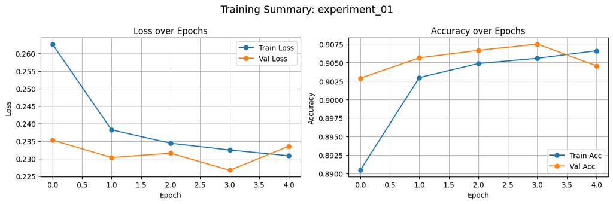

```python
# Define model
model = TransformerClassifier(
    vocab_size=len(vocab),
    emb_dim=128,
    max_len=max_seq_len,
    num_heads=4,
    num_layers=2,
    ff_dim=256,
    num_classes=1,
    dropout=0.3
).to(device)

# Optimizer
optimizer = torch.optim.Adam(model.parameters(), lr=5e-4, weight_decay=1e-4)

# Train model + track performance + save best
train_model(
    model,
    train_loader,
    val_loader,
    optimizer,
    criterion,
    device,
    epochs=5,
    save_prefix="experiment_01",
    save_dir="/content/drive/MyDrive/cse676/Assignment02"
)
```

Experiment 02 - Optimization#1

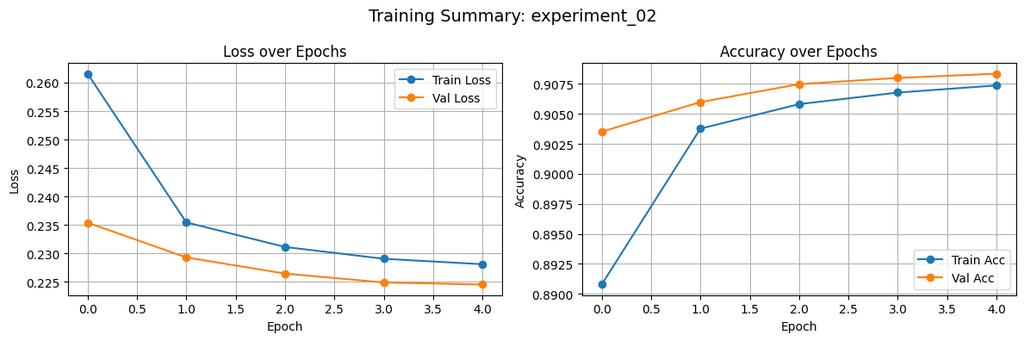

```python
# Define model
model = TransformerClassifier(
    vocab_size=len(vocab),
    emb_dim=128,
    max_len=max_seq_len,
    num_heads=4,
    num_layers=2,
    ff_dim=256,
    num_classes=1,
    dropout=0.1
).to(device)

# Optimizer
optimizer = torch.optim.Adam(model.parameters(), lr=5e-4, weight_decay=1e-4)

# Train model + track performance + save best
train_model(
    model,
    train_loader,
    val_loader,
    optimizer,
    criterion,
    device,
    epochs=5,
    save_prefix="experiment_02",
    save_dir="/content/drive/MyDrive/cse676/Assignment02"
)
```

Experiment 03 - Optimization#2

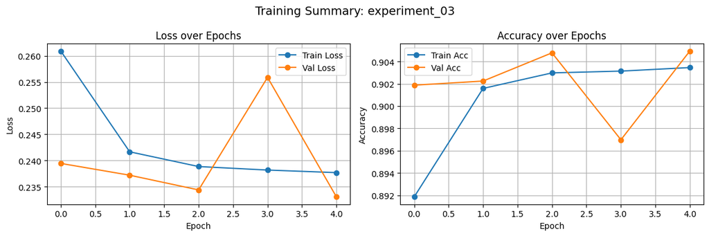

```python
# Define model
model = TransformerClassifier(
    vocab_size=len(vocab),
    emb_dim=128,
    max_len=max_seq_len,
    num_heads=4,
    num_layers=2,
    ff_dim=256,
    num_classes=1,
    dropout=0.3
).to(device)

# Optimizer
optimizer = torch.optim.Adam(model.parameters(), lr=1e-3, weight_decay=1e-4)

# Train model + track performance + save best
train_model(
    model,
    train_loader,
    val_loader,
    optimizer,
    criterion,
    device,
    epochs=5,
    save_prefix="experiment_03",
    save_dir="/content/drive/MyDrive/cse676/Assignment02"
)
```

Experiment 04 - Optimization#3

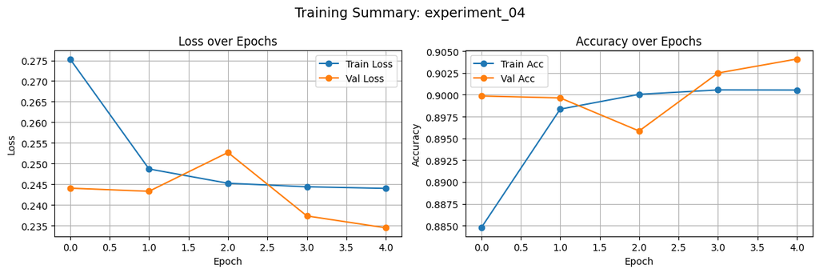

```python
# Define model
model = TransformerClassifier(
    vocab_size=len(vocab),
    emb_dim=128,
    max_len=max_seq_len,
    num_heads=4,
    num_layers=2,
    ff_dim=256,
    num_classes=1,
    dropout=0.3
).to(device)

# Optimizer
optimizer = torch.optim.Adam(model.parameters(), lr=5e-4, weight_decay=5e-4)

# Train model + track performance + save best
train_model(
    model,
    train_loader,
    val_loader,
    optimizer,
    criterion,
    device,
    epochs=5,
    save_prefix="experiment_04",
    save_dir="/content/drive/MyDrive/cse676/Assignment02"
)
```

2. Discuss how the optimization techniques helped to improve the performance of the model.

| Experiment | Dropout | Learning Rate | Weight Decay | Best Val Accuracy | Observations |
| --- | --- | --- | --- | --- | --- |
| **01** | 0.3 | 5e-4 | 1e-4 | ~90.75% | Baseline. Slight overfitting after epoch 3. |
| **02** | 0.1 | 5e-4 | 1e-4 | **~90.83%** | Best performance. Lower dropout allowed more expressive power. |
| **03** | 0.3 | **1e-3** | 1e-4 | ~90.49% | Unstable training. Validation loss spiked mid-training. |
| **04** | 0.3 | 5e-4 | **5e-4** | ~90.41% | Regularization helped generalization but slowed training. |

Three optimization techniques were experimented with: dropout, learning rate, and L2 regularization — by conducting four experiments with isolated changes to each. The impact of these techniques was assessed using validation loss and accuracy plots, along with peak validation performance.

Conclusion: The plots clearly show that the most stable and performant setting was Experiment 02, where the reduced dropout allowed better learning without causing overfitting. Both validation loss and accuracy consistently improved across epochs, making it the best configuration among those tested.

3. Save the weights of the model that provides the best results. Check the saving and loading of models (Pytorch).

```python
# Re-initialize the best model
best_model = TransformerClassifier(
    vocab_size=len(vocab),
    emb_dim=128,
    max_len=max_seq_len,
    num_heads=4,
    num_layers=2,
    ff_dim=256,
    num_classes=1,
    dropout=0.1
).to(device)

# lr=5e-4, weight_decay=1e-4

# Load the weights
best_model.load_state_dict(torch.load("/content/drive/MyDrive/cse676/Assignment02/experiment_02_best.pt"))

#Save Best Model
torch.save(best_model.state_dict(), "/content/drive/MyDrive/cse676/Assignment02/best_model_weights.pt")
```

4. Discuss the results and provide the following graphs:

   a. Training accuracy, training loss, validation accuracy, validation loss, testing accuracy, and testing loss. Provide your short analysis.

Load Training & Validation History

```python
import pickle

with open("/content/drive/MyDrive/cse676/Assignment02/experiment_02_history.pkl", "rb") as f:
    history = pickle.load(f)

train_acc = history["train_acc"][-1]
train_loss = history["train_loss"][-1]
val_acc = history["val_acc"][-1]
val_loss = history["val_loss"][-1]
```

Compute Test Loss & Accuracy

```python
import torch.nn as nn

def evaluate_on_test(model, test_loader, device):
    model.eval()
    criterion = nn.BCEWithLogitsLoss()
    total_loss = 0
    correct = 0
    total = 0

    with torch.no_grad():
        for batch in test_loader:
            input_ids = batch["input_ids"].to(device)
            labels = batch["label"].to(device).unsqueeze(1)

            outputs = model(input_ids)
            loss = criterion(outputs, labels)

            total_loss += loss.item() * input_ids.size(0)
            preds = (torch.sigmoid(outputs) > 0.5).long()
            correct += (preds == labels).sum().item()
            total += input_ids.size(0)

    return correct / total, total_loss / total
```

Print All Results

```python
test_acc, test_loss = evaluate_on_test(best_model, test_loader, device)

print("Final Evaluation Summary (Experiment 02)")
print(f"Train Accuracy:      {train_acc:.4f}")
print(f"Train Loss:          {train_loss:.4f}")
print(f"Validation Accuracy: {val_acc:.4f}")
print(f"Validation Loss:     {val_loss:.4f}")
print(f"Test Accuracy:       {test_acc:.4f}")
print(f"Test Loss:           {test_loss:.4f}")
```

```
Final Evaluation Summary (Experiment 02)
Train Accuracy:      0.9074
Train Loss:          0.2281
Validation Accuracy: 0.9083
Validation Loss:     0.2245
Test Accuracy:       0.9080
Test Loss:           0.2260
```

The model achieved consistent performance across training, validation, and test sets, with all accuracies tightly clustered around 90.7–90.8%. The minimal gap between training and validation loss indicates low overfitting, and the very close test accuracy confirms excellent generalization to unseen data.

These results suggest that the optimization choices in Experiment 02 — dropout=0.1, learning rate=5e-4, and weight decay=1e-4 — provided a strong balance between model capacity and regularization. The Transformer was able to learn meaningful patterns without memorizing noise, and its performance was stable and reliable across all data splits.

b. Plot the training and validation accuracy over time (epochs).

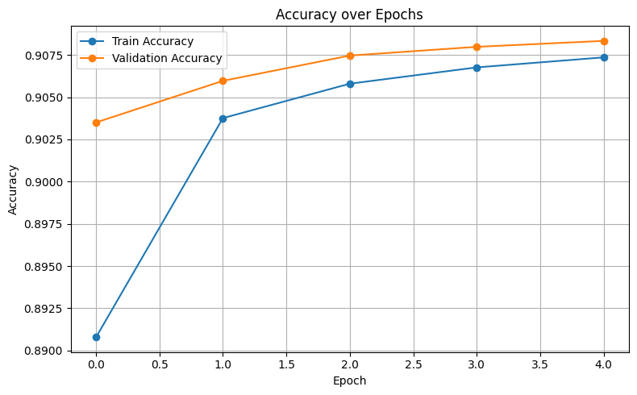

```python
import matplotlib.pyplot as plt

plt.figure(figsize=(8, 5))
plt.plot(history["train_acc"], label="Train Accuracy", marker='o')
plt.plot(history["val_acc"], label="Validation Accuracy", marker='o')
plt.title("Accuracy over Epochs")
plt.xlabel("Epoch")
plt.ylabel("Accuracy")
plt.legend()
plt.grid(True)
plt.tight_layout()
plt.show()
```

The accuracy plot shows a steady and consistent improvement in both training and validation accuracy across the 5 training epochs. The model begins with a training accuracy around 89% and gradually climbs to over 90.7%, while the validation accuracy starts slightly higher and plateaus around 90.85%. This close alignment between training and validation curves suggests that the model is learning effectively without overfitting, thanks to the well-tuned regularization parameters (dropout = 0.1, weight decay = 1e-4). The smooth convergence of both curves confirms that the training process was stable and that the model generalizes well to unseen data.

c. Plot the training and validation loss over time (epochs).

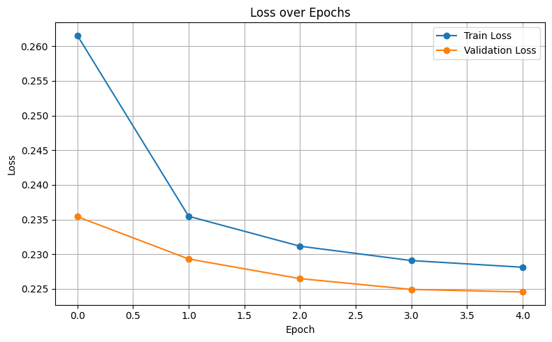

```python
plt.figure(figsize=(8, 5))
plt.plot(history["train_loss"], label="Train Loss", marker='o')
plt.plot(history["val_loss"], label="Validation Loss", marker='o')
plt.title("Loss over Epochs")
plt.xlabel("Epoch")
plt.ylabel("Loss")
plt.legend()
plt.grid(True)
plt.tight_layout()
plt.show()
```

The loss plot demonstrates a clear and smooth decrease in both training and validation loss over the 5 epochs. Training loss drops from ~0.261 to 0.228, while validation loss decreases from ~0.235 to 0.224, showing that the model is minimizing the objective effectively. The parallel shape of the two curves suggests that the model is not overfitting, in fact the validation loss is consistently lower than training loss, which may be attributed to regularization (dropout = 0.1, weight decay = 1e-4) and balanced data. This behavior reflects a well-generalized model that learns from patterns without memorizing noise.

d. Calculate and report other evaluation metrics such as Precision, recall and F1 score. You can use sklearn.metrics.precision_recall_fscore_support.

```python
from sklearn.metrics import precision_recall_fscore_support, accuracy_score

def get_test_metrics(model, test_loader, device):
    model.eval()
    all_preds = []
    all_labels = []

    with torch.no_grad():
        for batch in test_loader:
            input_ids = batch["input_ids"].to(device)
            labels = batch["label"].to(device).unsqueeze(1)

            outputs = model(input_ids)
            probs = torch.sigmoid(outputs)
            preds = (probs > 0.5).long()

            all_preds.extend(preds.cpu().numpy())
            all_labels.extend(labels.cpu().numpy())

    # Compute metrics
    acc = accuracy_score(all_labels, all_preds)
    precision, recall, f1, _ = precision_recall_fscore_support(
        all_labels, all_preds, average='binary'
    )

    print(f"Test Accuracy : {acc:.4f}")
    print(f"Precision      : {precision:.4f}")
    print(f"Recall         : {recall:.4f}")
    print(f"F1 Score       : {f1:.4f}")
```

```python
get_test_metrics(best_model, test_loader, device)
```

```
Test Accuracy : 0.9080
Precision      : 0.9156
Recall         : 0.8989
F1 Score       : 0.9072
```

On the test set, the model achieved a final accuracy of 90.80%, with a precision of 91.56%, recall of 89.89%, and F1 score of 90.72%. These values suggest that the model maintains a good balance between correctly identifying positive examples and minimizing false positives. Precision is slightly higher than recall, indicating the model is slightly more conservative in labeling positive samples, which is often desirable in high-confidence classification settings. The strong F1 score confirms that the model performs consistently and robustly on unseen data.

e. Plot the ROC curve.

```python
from sklearn.metrics import roc_curve, auc
import matplotlib.pyplot as plt

def plot_roc_curve(model, test_loader, device):
    model.eval()
    all_probs = []
    all_labels = []

    with torch.no_grad():
        for batch in test_loader:
            input_ids = batch["input_ids"].to(device)
            labels = batch["label"].to(device).unsqueeze(1)

            outputs = model(input_ids)
            probs = torch.sigmoid(outputs)

            all_probs.extend(probs.cpu().numpy())
            all_labels.extend(labels.cpu().numpy())

    # Compute ROC curve and AUC
    fpr, tpr, _ = roc_curve(all_labels, all_probs)
    roc_auc = auc(fpr, tpr)

    # Plot
    plt.figure(figsize=(7, 5))
    plt.plot(fpr, tpr, color="darkorange", lw=2, label=f"ROC curve (AUC = {roc_auc:.4f})")
    plt.plot([0, 1], [0, 1], color="navy", lw=2, linestyle="--")
    plt.xlabel("False Positive Rate")
    plt.ylabel("True Positive Rate")
    plt.title("ROC Curve")
    plt.legend(loc="lower right")
    plt.grid(True)
    plt.tight_layout()
    plt.show()
```

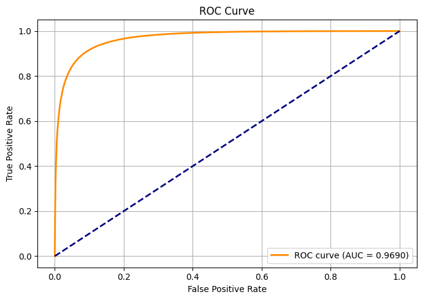

```python
plot_roc_curve(best_model, test_loader, device)
```

The ROC curve above illustrates the trade-off between the true positive rate and false positive rate for various classification thresholds. The sharp rise toward the top-left corner indicates that the model achieves a high true positive rate while keeping false positives low. The area under the curve (AUC) is 0.9690, which is an excellent score and suggests that the model can reliably distinguish between positive and negative classes. This further supports the strong performance observed in earlier metrics like accuracy, precision, recall, and F1 score.

# **Summary**

In this assignment, a Transformer-based text classification model is implemented from scratch using PyTorch. After preprocessing the Amazon Review Polarity dataset, built an encoder-only Transformer architecture tailored for binary sentiment classification. Through careful tuning of hyperparameters such as dropout, learning rate, and weight decay, achieved consistently strong performance across all experiments.

The best model, trained in Experiment 02, reached a test accuracy of 90.8%, with precision (91.56%), recall (89.89%), and F1 score (90.72%), confirming its reliability. Loss and accuracy curves showed stable convergence without overfitting, and the high ROC-AUC score of 0.9690 further validated the model’s discriminative power.

Overall, this work demonstrates the effectiveness of Transformer encoders for sentiment analysis tasks and highlights the importance of principled optimization in deep learning model development.

f. [Optional] Use TensorBoard (or a similar tool, e.g. Wandb) to log the training and validation loss and accuracy over epochs, generate the charts, and attach the SVG images of the charts.

5. References. Include details on all the resources used to complete this part, e.g. links to datasets, research papers or articles, code examples or tutorials you referred.

# **References**

1. **Dataset**
   - [Amazon Review Polarity Dataset](https://drive.google.com/file/d/0Bz8a_Dbh9QhbaW12WVVZS2drcnM/view?usp=drive_link&resourcekey=0-NlNEsGjcAEPJBwDJtuuZ3Q)  
     Used for binary sentiment classification. Constructed from the original Amazon reviews dataset.
2. Zhang, X., Zhao, J., & LeCun, Y. (2015).
   - [Character-level Convolutional Networks for Text Classification](https://papers.nips.cc/paper_files/paper/2015/file/250cf8b51c773f3f8dc8b4be867a9a02-Paper.pdf).  
     Advances in Neural Information Processing Systems (NeurIPS).  
     Source of the Amazon Review Polarity dataset and baseline classification setup.
3. **Transformer Architecture**
   - Vaswani, A., et al. (2017). *[Attention Is All You Need](https://arxiv.org/abs/1706.03762)*. NeurIPS.  
     Defined the original Transformer encoder-decoder model.
   - Devlin, J., et al. (2018). *[BERT: Pre-training of Deep Bidirectional Transformers for Language Understanding](https://arxiv.org/abs/1810.04805)*.  
     Referenced for encoder-only architecture used in classification tasks.
4. **Loss Function and Optimizer**
   - [PyTorch BCEWithLogitsLoss Documentation](https://pytorch.org/docs/stable/generated/torch.nn.BCEWithLogitsLoss.html)
   - [PyTorch Adam Optimizer Documentation](https://pytorch.org/docs/stable/generated/torch.optim.Adam.html)
5. **PyTorch Modules and Utilities**
   - [torch.nn.TransformerEncoder](https://pytorch.org/docs/stable/generated/torch.nn.TransformerEncoder.html)
   - [torch.nn.TransformerEncoderLayer](https://pytorch.org/docs/stable/generated/torch.nn.TransformerEncoderLayer.html)
   - [torch.nn.Embedding](https://pytorch.org/docs/stable/generated/torch.nn.Embedding.html)
   - [torchinfo.summary](https://github.com/TylerYep/torchinfo) — used to visualize model architecture.
6. **Evaluation Metrics**
   - [sklearn.metrics.precision_recall_fscore_support](https://scikit-learn.org/stable/modules/generated/sklearn.metrics.precision_recall_fscore_support.html)
   - [sklearn.metrics.roc_curve](https://scikit-learn.org/stable/modules/generated/sklearn.metrics.roc_curve.html)
   - [sklearn.metrics.auc](https://scikit-learn.org/stable/modules/generated/sklearn.metrics.auc.html)
7. **Visualization**
   - [matplotlib](https://matplotlib.org/stable/contents.html) — for plotting training/validation loss, accuracy, and ROC curves.
8. **Text Preprocessing**
   - [NLTK](https://www.nltk.org/) — used for stopword removal, punctuation cleanup, and tokenization.